# R Notebook

14E1. Add to the following model varying slopes on the predictor x.

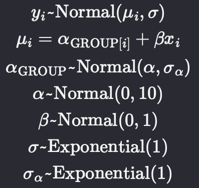

This is the original model.

**To add a varying slope on x, we have to add a dimension to the adaptive prior. This will mean that the β parameter becomes the average slope, and then we’ll need a new standard deviation parameter for the slopes and a correlation parameter to estimate the correlation between intercepts and slopes. The way this was done in the chapter, it’ll look like the following. Keep in mind that the precise notation varies among statisticians: sometimes (as below) vectors are in square brackets and matrices in parentheses, but others mix and match otherwise, or always use one or the other. As long as it is clear in context, it’ll be fine. And if anyone gives you grief about your notation, just remind (or inform) them that notational conventions vary and ask them which part requires clarification. If you use different priors for β and σ<sub>β</sub> and R, that’s fine. Just be sure your choices make sense to you.**

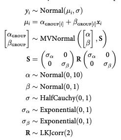

This is the modified model.

where the line beginning with S is one way of building a covariance matrix as outlined using from chapter 14 R code block 14.5, e.g.,

```r
r<-0.5
s<-c(1,10)
S<-diag(s,2,2)
R<-matrix(c(1,r,r,1),nrow=2)
S%*%R%*%S
```

```
##      [,1] [,2]
## [1,]    1    5
## [2,]    5  100
```

where s is the vector of sigma<sub>a</sub> and sigma<sub>b</sub> and r is the correlation between sigma<sub>a</sub> and sigma<sub>b</sub>.

14E2. Think up a context in which varying intercepts will be positively correlated with varying slopes. Provide a mechanistic explanation for the correlation.

**This is an open, imaginative problem. So instead of providing a precise answer, let me provide the structure that is being asked for. Then I’ll follow it was some brief examples. When intercepts and slopes are correlated, it means that clusters in the data that have high baselines also have stronger positive associations with a predictor variable. This is merely descriptive. So the mechanistic explanations that are consistent with it are highly diverse. A very common example comes from educational testing. In this context, clusters are individual schools and observations are individual student test scores. Schools with high average test scores also tend to show greater differences (a larger slope) between poor and rich students within the school. In growth data, large individuals also tend to grow faster. So for any interval of measurement, the repeat measures of size for individuals show a positive correlation between beginning height (intercept) and the slope across time. In financial data, for very similar reasons, large investments tend to grow faster. So again, intercepts tend to be positively associated with slopes.**

14E3. When is it possible for a varying slopes model to have fewer effective parameters (as estimated by WAIC or PSIS) than the corresponding model with fixed (unpooled) slopes? Explain.

**It possible for a varying effects model to actually have fewer effective parameters than a corresponding fixed effect model when there is very little variation among clusters. This will create strong shrinkage of the estimates, constraining the individual varying effect parameters. So even though the varying effects model must have more actual parameters in the posterior distribution, it can be less flexible in fitting the data, because it adaptively regularizes. There’s really nothing special about varying slopes in this respect. Varying intercepts work the same way. Here’s an example. (But to answer this problem, you did not need to provide a computational example.)**

**Let’s simulate some data in which there are clusters, but they aren’t very different from one another. For the sake of comprehension, let’s suppose the clusters are individuals and the observations are test scores. Each individual will have a unique “ability” that influences each test score. Our goal in estimation will be to recover these abilities.**

```r
N_individuals <- 100
N_scores_per_individual <- 10
# simulate abilities
ability <- rnorm(N_individuals,0,0.1)
# simulate observed test scores
# sigma here large relative to sigma of ability
N <- N_scores_per_individual * N_individuals
id <- rep(1:N_individuals,each=N_scores_per_individual)
score <- round( rnorm(N,ability[id],1) , 2 )
# put observable variables in a data frame
d <- data.frame(
id = id,
score = score )
```

**Now let’s fit a fixed effect model. This is the “unpooled” model with an intercept for each individual, but with a fixed prior.**

```r
require(rethinking)
m_nopool <- ulam(
alist(
score ~ dnorm(mu,sigma),
mu <- a_id[id],
a_id[id] ~ dnorm(0,10),
sigma ~ dexp(1)
), data=d , chains=4 , log_lik=TRUE )
```

[output not shown]

**And this is the corresponding “partial pooling” model with an adaptive prior, the varying effects model.**

```r
m_partpool <- ulam(
alist(
score ~ dnorm(mu,sigma),
mu <- a + z_id[id]*sigma_id,
z_id[id] ~ dnorm(0,1),
a ~ dnorm(0,10),
sigma ~ dexp(1),
sigma_id ~ dexp(1)
), data=d , chains=4 , log_lik=TRUE )
```

[output not shown]

[output not shown]

[output not shown]

[output not shown]

[output not shown]

```
## Chain 2
```

[output not shown]

**Now let’s compare their effective parameters, as computed by WAIC. But first, let’s count the actual parameters in each model. The model m_nopool has 100 intercepts (one for each individual) and one standard deviation parameter, for 101 parameters total. The model m_partpool has 100 varying intercepts, one average intercept a, and two standard deviation parameters, for 103 parameters total. Now let’s compare:**

```r
compare( m_nopool , m_partpool )
```

|  | WAIC | SE | dWAIC | dSE | pWAIC | weight |
| --- | --- | --- | --- | --- | --- | --- |
| m_partpool | 2837.260 | 45.18475 | 0.0000 | NA | 23.41789 | 1.000000e+00 |
| m_nopool | 2912.884 | 44.39370 | 75.6241 | 17.6636 | 96.33136 | 3.788222e-17 |

**The partial pooling model only has many fewer effective parameters than the no-pool model (given by the pWAIC column). You can see why m_partpool has so many fewer effective parameters than actual parameters by looking at the posterior for sigma_id:**

```r
precis(m_partpool)
```

```
## 100 vector or matrix parameters hidden. Use depth=2 to show them.
```

|  | mean | sd | 5.5% | 94.5% | rhat | ess_bulk |
| --- | --- | --- | --- | --- | --- | --- |
| a | 0.006254554 | 0.03569979 | -0.05160188 | 0.06257369 | 1.000267 | 3092.9531 |
| sigma | 0.988659902 | 0.02314789 | 0.95211146 | 1.02565935 | 1.004141 | 2115.0631 |
| sigma_id | 0.152481158 | 0.06460302 | 0.03410095 | 0.24616210 | 1.017777 | 389.6379 |

**The posterior mean for sigma_id is relatively small, inducing a lot of shrinkage. Those 100 parameters are only as flexible as a far smaller number of parameters. This emphasizes something very important about model “complexity”: the number of dimensions in a model is not a relevant measure of complexity in terms of judging overfitting risk. This should warn us off using any intuitive measure of complexity when employing Occam’s Razor style reasoning. Just because one model makes more assumptions than another (has more parameters or distributions), that does not always mean that it overfits more. In statistics, “simple” just doesn’t mean what in means in plain English.**